# Practicum I - Design & Implement a Relational Database on Bird Strikes on Aircraft

# 1.0 CONNECTING TO THE AWS DATABASE

```r
# 1. Library
library(RMySQL)

# 2. Settings
db_user <- 'admin'
db_password <- 'Welcome123'
db_name <- 'Practicum1'
db_host <- 'cs5200-dbs.cylccrkwyet2.us-east-1.rds.amazonaws.com' # AWS Host
db_port <- 3306

# 3. Read data from db
mydb <-  dbConnect(MySQL(), user = db_user, password = db_password,
                 dbname = db_name, host = db_host, port = db_port)
```

# 2.0 CREATING TABLES

## 2.1 Dropping tables

We will need to create 3 tables - Airports, Condtions and Incidents. We will drop these tables first if they exists.

```sql
DROP TABLE IF EXISTS Incidents;
```

```sql
DROP TABLE IF EXISTS Airports;
```

```sql
DROP TABLE IF EXISTS Conditions;
```

## 2.1 Create a table that stores airports and states called airports(aid, airportName, airportCode, state). aid is a synthetic primary key, airportName and state are the airport name and state from the data file.

```sql
CREATE TABLE Airports (aid INT NOT NULL AUTO_INCREMENT,
                       airportname VARCHAR(30),
                       airportcode VARCHAR(10),
                       state VARCHAR(30),
                       PRIMARY KEY(aid)
                       )
```

## 2.3 Create a lookup table conditions(cid, condition, explanation) and link this lookup table to the incidents table with the conditions foreign key. This table contains the value of all conditions, e.g., ‘Overcast’. Leave the explanation column empty (future expansion).

```sql
CREATE TABLE Conditions (cid INT NOT NULL AUTO_INCREMENT,
                         `condition` VARCHAR(20),
                         explanation VARCHAR(80),
                         PRIMARY KEY(cid)
                         )
```

## 2.4 Create a table that stores wildlife strike incidents called incidents(rid, date, origin, airline, aircraft, flightPhase, altitude, conditions, warning). Only store the date, not the time of the incident. Make ‘warning’ a Boolean flag and use TRUE if the pilot was warned, FALSE otherwise.

```sql
CREATE TABLE Incidents (rid INT PRIMARY KEY,
                        flightdate DATE,
                        origin INT,
                        airline VARCHAR(30),
                        aircraft VARCHAR(30),
                        flightphase ENUM('takeoff', 'landing', 'inflight', 'unknown') NOT NULL,
                        altitude INT,
                        conditions INT,
                        warning BOOLEAN,
                        FOREIGN KEY (origin) REFERENCES Airports(aid),
                        FOREIGN KEY (conditions) REFERENCES Conditions(cid)
                        );
```

```sql
#Displaying all the tables in the database
SHOW TABLES;
```

| Tables_in_Practicum1 |
| --- |
| Airports |
| Conditions |
| Incidents |
| v_flightPhase |

# 3.0 LOADING DATA

## 3.1 Loading the .csv file

```r
df.raw <- read.csv("BirdStrikesData-V2.csv", header = TRUE, stringsAsFactors = FALSE, strip.white = TRUE)

paste("Number of columns in the dataframe: ", ncol(df.raw))
```

```
[1] "Number of columns in the dataframe:  19"
```

```r
paste("Number of columns in the dataframe: ", nrow(df.raw))
```

```
[1] "Number of columns in the dataframe:  25558"
```

## 3.2 Let’s clean the data

```r
# Remove records (rows) that do not have flight information.
df.raw <- df.raw[!(df.raw$airline==""),]

# Remove all military flights from the database.
df.raw <- df.raw[!grepl("military",df.raw$airline, ignore.case=TRUE),]

paste("Number of columns in the dataframe: ", ncol(df.raw))
```

```
[1] "Number of columns in the dataframe:  19"
```

```r
paste("Number of columns in the dataframe: ", nrow(df.raw))
```

```
[1] "Number of columns in the dataframe:  25340"
```

## 3.3 Create Dataframes

The strategy we will use to load the data from the CSV to the database is to create internal data frames that mirror the tables in the database and then write the data frames to the database. So we will create 3 data frames - **Airports**, **Conditions** and **Incidents**.

### 3.3.1 Creating dataframe ‘Airports’

We will need to find the unique set of airports, so we will remove duplicates, any blank strings, etc. Also add a synthetic key column in the data frame.

```r
df.airports <- df.raw[,c("airport", "origin")]

#remove duplicates, NA values and blank values.
df.airports <- df.airports[!duplicated(df.airports), ]

paste("Number of columns in the dataframe: ", ncol(df.airports))
```

```
[1] "Number of columns in the dataframe:  2"
```

```r
paste("Number of columns in the dataframe: ", nrow(df.airports))
```

```
[1] "Number of columns in the dataframe:  1107"
```

#### Let’s check if there is any blank or null values in the airportName column

```r
any(is.na(df.airports))
```

```
[1] FALSE
```

#### Let’s further make some changes - add airport ID, airport code and rearrange the columns

```r
#add 'aid' column
df.airports$aid <- seq.int(nrow(df.airports))

#renaming the column names
colnames(df.airports) <- c('airportName','state','aid')

#add 'airportCode' column
df.airports <- cbind(df.airports,airportCode="")

#rearranging column names
df.airports <- df.airports[,c(3,1,4,2)]

#display the data frame
df.airports
```

|  | aid | airportName | airportCode | state |
| --- | --- | --- | --- | --- |
| 1 | 1 | LAGUARDIA NY |  | New York |
| 2 | 2 | DALLAS/FORT WORTH INTL ARPT |  | Texas |
| 3 | 3 | LAKEFRONT AIRPORT |  | Louisiana |
| 4 | 4 | SEATTLE-TACOMA INTL |  | Washington |
| 5 | 5 | NORFOLK INTL |  | Virginia |
| 6 | 6 | GUAYAQUIL/S BOLIVAR |  | N/A |
| 7 | 7 | NEW CASTLE COUNTY |  | Delaware |
| 8 | 8 | WASHINGTON DULLES INTL ARPT |  | DC |
| 9 | 9 | ATLANTA INTL |  | Georgia |
| 10 | 10 | ORLANDO SANFORD INTL AIRPORT |  | Florida |

[output cut: 990 more lines]

### 3.3.2 Creating dataframe ‘Conditions’

We will need to find the unique set of conditions, so we will remove duplicates, any blank strings, etc. Also add a synthetic key column in the data frame.

```r
# create a data frame
df.conditions <- data.frame(condition = c(df.raw[,c("sky_conditions")]))

#remove duplicates.
df.conditions <- data.frame(condition = df.conditions[!duplicated(df.conditions$condition), ])

#adding cid column
df.conditions <- tibble::rowid_to_column(df.conditions, "cid")

#add 'explanation' column
df.conditions <- cbind(df.conditions, explanation="")

df.conditions
```

| cid | condition | explanation |
| --- | --- | --- |
| 1 | No Cloud |  |
| 2 | Some Cloud |  |
| 3 | Overcast |  |

```r
NA
```

### 3.3.2 Creating dataframe ‘Incidents’

```r
# create a data frame
df.incidents <- data.frame(rid = c(df.raw[,c("rid")]),
                           flightdate = c(df.raw[,c("flight_date")]),
                           origin = c(df.raw[,c("origin")]),
                           airline = c(df.raw[,c("airline")]),
                           aircraft = c(df.raw[,c("aircraft")]),
                           flightphase = c(df.raw[,c("flight_phase")]),
                           altitude = c(df.raw[,c("altitude_ft")]),
                           conditions = c(df.raw[,c("sky_conditions")]),
                           warning = c(df.raw[,c("pilot_warned_flag")]))

colnames(df.incidents)
```

```
[1] "rid"         "flightdate"  "origin"      "airline"     "aircraft"    "flightphase" "altitude"
[8] "conditions"  "warning"
```

```r
df.incidents
```

| rid | flightdate | origin | airline | aircraft | flightphase | altitude | conditions | warning |
| --- | --- | --- | --- | --- | --- | --- | --- | --- |
| 202152 | 11/23/2000 0:00 | New York | US AIRWAYS* | Airplane | Climb | 1,500 | No Cloud | N |
| 208159 | 7/25/2001 0:00 | Texas | AMERICAN AIRLINES | Airplane | Landing Roll | 0 | Some Cloud | Y |
| 207601 | 9/14/2001 0:00 | Louisiana | BUSINESS | Airplane | Approach | 50 | No Cloud | N |
| 215953 | 9/5/2002 0:00 | Washington | ALASKA AIRLINES | Airplane | Climb | 50 | Some Cloud | Y |
| 219878 | 6/23/2003 0:00 | Virginia | COMAIR AIRLINES | Airplane | Approach | 50 | No Cloud | N |
| 218432 | 7/24/2003 0:00 | N/A | AMERICAN AIRLINES | Airplane | Take-off run | 0 | No Cloud | N |
| 221697 | 8/17/2003 0:00 | Delaware | BUSINESS | Airplane | Climb | 150 | No Cloud | N |
| 236635 | 3/1/2006 0:00 | DC | UNITED AIRLINES | Airplane | Approach | 100 | Some Cloud | Y |
| 207369 | 1/6/2000 0:00 | Georgia | AIRTRAN AIRWAYS | Airplane | Take-off run | 0 | Some Cloud | N |
| 204371 | 1/7/2000 0:00 | Florida | AIRTOURS INTL | Airplane | Landing Roll | 0 | Some Cloud | N |

[output cut: 990 more lines]

#### Let’s now clean up and process the data in the incidents data frame.

```r
#convert the flight date column into date
df.incidents$flightdate = as.Date(df.incidents$flightdate, format = "%m/%d/%Y")

# change warning flag to TRUE and FALSE
df.incidents$warning[df.incidents$warning == "N"] <- "FALSE"
df.incidents$warning[df.incidents$warning == "Y"] <- "TRUE"

# change the conditions as per our conditions table
df.incidents$conditions[df.incidents$conditions == "No Cloud"] <- 1
df.incidents$conditions[df.incidents$conditions == "Some Cloud"] <- 2
df.incidents$conditions[df.incidents$conditions == "Overcast"] <- 3

df.incidents
```

| rid | flightdate | origin | airline | aircraft | flightphase | altitude | conditions | warning |
| --- | --- | --- | --- | --- | --- | --- | --- | --- |
| 202152 | 2000-11-23 | New York | US AIRWAYS* | Airplane | Climb | 1,500 | 1 | FALSE |
| 208159 | 2001-07-25 | Texas | AMERICAN AIRLINES | Airplane | Landing Roll | 0 | 2 | TRUE |
| 207601 | 2001-09-14 | Louisiana | BUSINESS | Airplane | Approach | 50 | 1 | FALSE |
| 215953 | 2002-09-05 | Washington | ALASKA AIRLINES | Airplane | Climb | 50 | 2 | TRUE |
| 219878 | 2003-06-23 | Virginia | COMAIR AIRLINES | Airplane | Approach | 50 | 1 | FALSE |
| 218432 | 2003-07-24 | N/A | AMERICAN AIRLINES | Airplane | Take-off run | 0 | 1 | FALSE |
| 221697 | 2003-08-17 | Delaware | BUSINESS | Airplane | Climb | 150 | 1 | FALSE |
| 236635 | 2006-03-01 | DC | UNITED AIRLINES | Airplane | Approach | 100 | 2 | TRUE |
| 207369 | 2000-01-06 | Georgia | AIRTRAN AIRWAYS | Airplane | Take-off run | 0 | 2 | FALSE |
| 204371 | 2000-01-07 | Florida | AIRTOURS INTL | Airplane | Landing Roll | 0 | 2 | FALSE |

[output cut: 990 more lines]

```r
unique(df.incidents$flightphase)
```

```
[1] "Climb"        "Landing Roll" "Approach"     "Take-off run" "Descent"      "Taxi"
[7] "Parked"
```

#### Now, we will harmonize the flight phases to be one of: takeoff, landing, inflight, unknown.

```r
df.incidents$flightphase[df.incidents$flightphase == "Climb"] <-"inflight"
df.incidents$flightphase[df.incidents$flightphase == "Landing Roll"] <-"landing"
df.incidents$flightphase[df.incidents$flightphase == "Approach"] <-"landing"
df.incidents$flightphase[df.incidents$flightphase == "Take-off run"] <-"takeoff"
df.incidents$flightphase[df.incidents$flightphase == "Descent"] <-"landing"
df.incidents$flightphase[df.incidents$flightphase == "Taxi"] <-"unknown"
df.incidents$flightphase[df.incidents$flightphase == "Parked"] <-"unknown"

unique(df.incidents$flightphase)
```

```
[1] "inflight" "landing"  "takeoff"  "unknown"
```

#### Now let’s check if the data frame has any missing, NA, null or duplicated values

```r
paste("The NA values in Incidents dataframe is",any(is.na(df.incidents)))
```

```
[1] "The NA values in Incidents dataframe is FALSE"
```

```r
paste("The duplicated values in Incidents dataframe is",anyDuplicated(df.incidents))
```

```
[1] "The duplicated values in Incidents dataframe is 0"
```

```r
paste("The null values in Incidents dataframe is", any(is.null(df.incidents)))
```

```
[1] "The null values in Incidents dataframe is FALSE"
```

#### Let’s replace the “origin” column in df.Incidents with “aid” from df.airports

```r
df.incidents$origin <- df.airports$aid[match(df.incidents$origin, df.airports$state)]

df.incidents
```

| rid | flightdate | origin | airline | aircraft | flightphase | altitude | conditions | warning |
| --- | --- | --- | --- | --- | --- | --- | --- | --- |
| 202152 | 2000-11-23 | 1 | US AIRWAYS* | Airplane | inflight | 1,500 | 1 | FALSE |
| 208159 | 2001-07-25 | 2 | AMERICAN AIRLINES | Airplane | landing | 0 | 2 | TRUE |
| 207601 | 2001-09-14 | 3 | BUSINESS | Airplane | landing | 50 | 1 | FALSE |
| 215953 | 2002-09-05 | 4 | ALASKA AIRLINES | Airplane | inflight | 50 | 2 | TRUE |
| 219878 | 2003-06-23 | 5 | COMAIR AIRLINES | Airplane | landing | 50 | 1 | FALSE |
| 218432 | 2003-07-24 | 6 | AMERICAN AIRLINES | Airplane | takeoff | 0 | 1 | FALSE |
| 221697 | 2003-08-17 | 7 | BUSINESS | Airplane | inflight | 150 | 1 | FALSE |
| 236635 | 2006-03-01 | 8 | UNITED AIRLINES | Airplane | landing | 100 | 2 | TRUE |
| 207369 | 2000-01-06 | 9 | AIRTRAN AIRWAYS | Airplane | takeoff | 0 | 2 | FALSE |
| 204371 | 2000-01-07 | 10 | AIRTOURS INTL | Airplane | landing | 0 | 2 | FALSE |

[output cut: 990 more lines]

```r
NA
```

### 3.4 Loading the data from dataframes to MySql tables

```r
dbWriteTable(mydb, "Conditions", df.conditions, overwrite = F, append = T, row.names = F);
```

```
[1] TRUE
```

```r
dbWriteTable(mydb, "Airports", df.airports, overwrite = F, append = T, row.names = F);
```

```
[1] TRUE
```

```r
dbWriteTable(mydb, "Incidents", df.incidents, overwrite = F, append = T, row.names = F);
```

```
[1] TRUE
```

# 4.0 DISPLAYING THE DATA FROM THE TABLES

```r
sqlStmt <- "SELECT * FROM Conditions;"
result = dbGetQuery(conn=mydb,sqlStmt)
print(result)
```

| cid | condition | explanation |
| --- | --- | --- |
| 1 | No Cloud |  |
| 2 | Some Cloud |  |
| 3 | Overcast |  |

```r
NA
```

```r
sqlStmt <- "SELECT * FROM Airports LIMIT 50;"
result = dbGetQuery(conn=mydb,sqlStmt)
print(result)
```

| aid | airportname | airportcode | state |
| --- | --- | --- | --- |
| 1 | LAGUARDIA NY |  | New York |
| 2 | DALLAS/FORT WORTH INTL ARPT |  | Texas |
| 3 | LAKEFRONT AIRPORT |  | Louisiana |
| 4 | SEATTLE-TACOMA INTL |  | Washington |
| 5 | NORFOLK INTL |  | Virginia |
| 6 | GUAYAQUIL/S BOLIVAR |  | N/A |
| 7 | NEW CASTLE COUNTY |  | Delaware |
| 8 | WASHINGTON DULLES INTL ARPT |  | DC |
| 9 | ATLANTA INTL |  | Georgia |
| 10 | ORLANDO SANFORD INTL AIRPORT |  | Florida |

[output cut: 40 more lines]

```r
NA
```

```r
sqlStmt <- "SELECT * FROM Incidents LIMIT 50;"
result = dbGetQuery(conn=mydb,sqlStmt)
print(result)
```

| rid | flightdate | origin | airline | aircraft | flightphase | altitude | conditions | warning |
| --- | --- | --- | --- | --- | --- | --- | --- | --- |
| 200011 | 2000-04-06 | 47 | ABX AIR | Airplane | landing | 0 | 3 | 0 |
| 200012 | 2000-04-10 | 93 | AIR MIDWEST | Airplane | landing | 0 | 3 | 0 |
| 200022 | 2000-02-28 | 2 | AMERICAN EAGLE AIRLINES | Airplane | landing | 2 | 1 | 0 |
| 200023 | 2000-08-25 | 10 | US AIRWAYS* | Airplane | landing | 7 | 1 | 0 |
| 200028 | 2000-03-22 | 102 | UNITED AIRLINES | Airplane | landing | 3 | 1 | 0 |
| 200029 | 2000-05-14 | 40 | BUSINESS EXPRESS | Airplane | landing | 30 | 1 | 0 |
| 200031 | 2000-06-12 | 24 | GREAT LAKES AIRLINES | Airplane | landing | 500 | 1 | 0 |
| 200036 | 2000-09-29 | 93 | BUSINESS | Airplane | inflight | 1 | 1 | 0 |
| 200037 | 2001-02-01 | 11 | UNITED AIRLINES | Airplane | takeoff | 0 | 2 | 0 |
| 200042 | 2000-08-31 | 41 | FEDEX EXPRESS | Airplane | landing | 400 | 2 | 0 |

[output cut: 40 more lines]

```r
NA
```

```r
sqlStmt <- "SELECT COUNT(*) FROM Incidents;"
result = dbGetQuery(conn=mydb,sqlStmt)
print(result)
```

| COUNT(*) |
| --- |
| 25340 |

```r
NA
```

# 5.0 WRITING SQL QUERIES

## 5.1 Create a SQL query against your database to find the 10 airlines with the greatest number of incidents.

```r
sqlStmt <- "SELECT
  airline, COUNT(rid) as Number_of_incidents
FROM
  Incidents
GROUP BY
  airline
ORDER BY
  Number_of_incidents desc
LIMIT 10;"
result = dbGetQuery(conn=mydb,sqlStmt)
print(result)
```

| airline | Number_of_incidents |
| --- | --- |
| SOUTHWEST AIRLINES | 4628 |
| BUSINESS | 3074 |
| AMERICAN AIRLINES | 2058 |
| DELTA AIR LINES | 1349 |
| AMERICAN EAGLE AIRLINES | 932 |
| SKYWEST AIRLINES | 891 |
| US AIRWAYS* | 797 |
| JETBLUE AIRWAYS | 708 |
| UPS AIRLINES | 590 |
| US AIRWAYS | 540 |

```r
NA
```

## 5.2 Create a SQL query against your database to find the flight phase that had an above average number bird strike incidents (during any flight phase).

```r
drop = dbExecute(conn = mydb, statement = "DROP VIEW v_flightPhase;")

sqlcreateView <- "CREATE VIEW v_flightPhase AS
                  SELECT
                    flightPhase, COUNT(*) AS noOfIncidents
                  FROM
                    Incidents
                  GROUP BY
                    flightPhase;"

result1 <- dbExecute(conn = mydb, statement = sqlcreateView)

sqlStmt <- "SELECT * FROM
              v_flightPhase
            WHERE
              noOfIncidents > (SELECT AVG(noOfIncidents) FROM v_flightPhase);"

result2 <- dbGetQuery(conn = mydb, statement = sqlStmt)

print(result2)
```

| flightPhase | noOfIncidents |
| --- | --- |
| landing | 16166 |

```r
NA
```

## 5.3 Create a SQL query against your database to find the number of bird strike incidents by month (across all years). Include all airlines and all flights.

```r
sqlStmt <- "SELECT EXTRACT(month FROM flightdate) AS month, count(rid) as number_of_incidents
FROM Incidents
GROUP BY month
ORDER BY month ASC;"
result = dbGetQuery(conn=mydb,sqlStmt)
print(result)
```

| month | number_of_incidents |
| --- | --- |
| 1 | 933 |
| 2 | 765 |
| 3 | 1229 |
| 4 | 1819 |
| 5 | 2307 |
| 6 | 2070 |
| 7 | 3264 |
| 8 | 3704 |
| 9 | 3413 |
| 10 | 3026 |

[output cut: 2 more lines]

```r
NA
```

# 6.0 BUILDING CHARTS

## 6.1 Build a line chart that visualizes the number of bird strikes incidents per year from 2005 to 2011. Adorn the graph with appropriate axis labels, titles, legend, data labels, etc.

##### First finding the bird strikes per year > 2004 using sql command

```r
sqlStmt <- "SELECT EXTRACT(year FROM flightdate) AS year, count(rid) as number_of_incidents
FROM Incidents
GROUP BY year
ORDER BY year asc;"

birdStrikeByYear = dbGetQuery(conn=mydb,sqlStmt)
birdStrikeByYear <- subset(birdStrikeByYear, year>2004)
print(birdStrikeByYear)
```

|  | year | number_of_incidents |
| --- | --- | --- |
| 6 | 2005 | 1853 |
| 7 | 2006 | 2159 |
| 8 | 2007 | 2301 |
| 9 | 2008 | 2258 |
| 10 | 2009 | 3247 |
| 11 | 2010 | 3121 |
| 12 | 2011 | 2952 |

```r
NA
```

#### Next, plotted the values in r

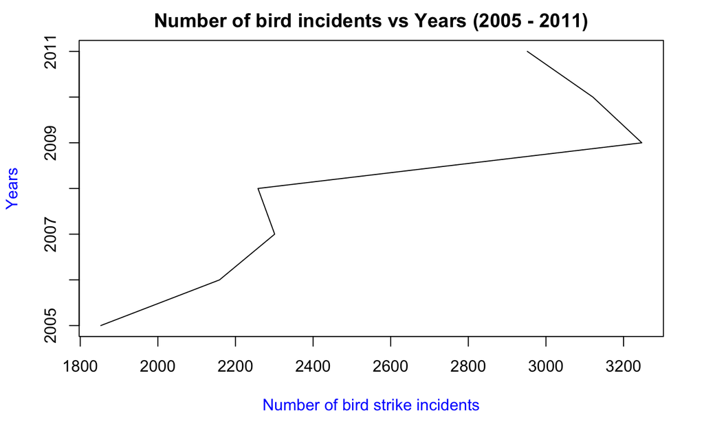

```r
# Data
x <- birdStrikeByYear$number_of_incidents
y <- birdStrikeByYear$year

# plotting the line chart
plot(x, y, type = "l",
     xlab ="Number of bird strike incidents",
     ylab = "Years",
     col.lab = "blue",
     main = "Number of bird incidents vs Years (2005 - 2011)"
     )
```

# 7.0 WRITING STORED PROCEDURE

## 7.1 Create a stored procedure in MySQL that adds a new incident to the database. You may decide what you need to pass to the stored procedure to add a bird strike incident and you must account for there being potentially a new airport. After insertion, show (in R) that your procedure worked.

```sql
DROP PROCEDURE IF EXISTS insert_new_incident;
```

```sql
CREATE PROCEDURE insert_new_incident
                        (IN rid INT,
                        IN flightdate DATE,
                        IN origin INT,
                        IN airline VARCHAR(30),
                        IN aircraft VARCHAR(30),
                        IN flightphase ENUM('takeoff', 'landing', 'inflight', 'unknown'),
                        IN altitude INT,
                        IN conditions INT,
                        IN warning BOOLEAN,
                        IN airportname VARCHAR(30),
                        IN airportcode VARCHAR(10),
                        IN state VARCHAR(30))
BEGIN

IF origin NOT IN (SELECT aid FROM Airports) THEN
INSERT INTO Airports (aid, airportName, airportCode, state) VALUES (origin, airportname, airportcode, state);
END IF;

INSERT INTO Incidents (rid, flightdate, origin, airline, aircraft, flightphase, altitude, conditions, warning)
VALUES (rid, flightdate, origin, airline, aircraft, flightphase, altitude, conditions, warning);

END
```

# 8.0 TESTING

## 8.1 Testing the stored procedure

### TEST 1: We will try to call the stored procedure by passing the values where “origin” exists in the “Airports” table

```sql
CALL insert_new_incident(30001, 10/05/2022, 5, "Southwest Airlines", "B-737-700", "landing", 15000, 1, "TRUE","Boston Logan","BOS","Massachusetts")
```

```sql
SELECT * from Incidents where rid = 30001
```

| rid | flightdate | origin | airline | aircraft | flightphase | altitude | conditions | warning |
| --- | --- | --- | --- | --- | --- | --- | --- | --- |
| 30001 | 0000-00-00 | 5 | Southwest Airlines | B-737-700 | landing | 15000 | 1 | 0 |

#### TEST 1 RESULTS - PASSED: We tried to pass “Boston Logan”, “Bos” and “Massachusetts” in the procedure call. Below is the proof that the stored procedure did not update the “Airports” table with the data passed in the stored procedure as origin=5 already existed in the “Airports” table

```sql
SELECT * from Airports where aid = 5
```

| aid | airportname | airportcode | state |
| --- | --- | --- | --- |
| 5 | NORFOLK INTL |  | Virginia |

### TEST 2: We will try to call the stored procedure by passing the values where “origin” DOES NOT exist in the “Airports” table. Example here aid = 2000 does not exist in the “Airports” table

```sql
CALL insert_new_incident(30002, 10/05/2022, 2000, "Southwest Airlines", "B-737-700", "landing", 15000, 1, "TRUE","Boston Logan","BOS","Massachusetts")
```

```sql
SELECT * from Incidents where rid = 30002
```

| rid | flightdate | origin | airline | aircraft | flightphase | altitude | conditions | warning |
| --- | --- | --- | --- | --- | --- | --- | --- | --- |
| 30002 | 0000-00-00 | 2000 | Southwest Airlines | B-737-700 | landing | 15000 | 1 | 0 |

#### TEST 2 RESULTS - PASSED: We tried to pass “Boston Logan”, “Bos” and “Massachusetts” in the procedure call. Below is the proof that the stored procedure successfully inserted the tuple into the “Airports” table with these values.

```sql
SELECT * from Airports where aid = 2000
```

| aid | airportname | airportcode | state |
| --- | --- | --- | --- |
| 2000 | Boston Logan | BOS | Massachusetts |

#### Disconnecting from the database

```r
dbDisconnect(mydb)
```

```
[1] TRUE
```